# Chapter 3 - Discrete Probability Distribution

Dr. Alessandro Ruggieri

### Binomal distribution

A random variable distributed as a Binomial(n,p) has a density equal to $p(x) = C(n, x) p^x (1-p)^{(n-x)}$ for $x>0$. The mean is equal to E(x)=$np$ while the variance is Var(x)=$np (1 − p)$

We can compute the density p(x) using the function dbinom( )

```r
# trials
n<-10
# probability
p<-0.3
# number of success
x<-3
# density at x (probability of x successes out of n trial)
dbinom(x,n, p)
```

```
## [1] 0.2668279
```

We can also compute the distribution function P(x) using the function pbinom( )

```r
# distribution function at x  (probability of up to x successes out of n trial)
pbinom(x, n, p)
```

```
## [1] 0.6496107
```

Alternatively, we can also compute the distribution function by summing the densities accordingly, i.e.

```r
# distribution function at x = 3
out<-0
i<-0
while(i<= 3) {
  dist<-dbinom(i,n, p)
  out = dist +out
  i<-i+1
}
out
```

```
## [1] 0.6496107
```

```r
# lower bound - minimum number of successes
a<-2
# upper bound - maximum number of successes
b<-5
# probability number of successes is between and and bout of n trial
sum(dbinom(a:b, n, p))
```

```
## [1] 0.8033427
```

or alternative, we can use the function pbinom( ) and subtract the distribution evaluated at a-1 to the distribution evaluated at b, i.e

```r
# probability number of successes is between a and b out of n trial
pbinom(b, n, p) - pbinom(a-1, n, p)
```

```
## [1] 0.8033427
```

Notice that the Bernulli distribution can be understood as a Binomial for the case of n=1 trial.

If we want to draw a k numbers from a Binomial distribution B(n,p), we can use the function rbinom( ):

```r
# numbers to draw
k<-10000
# draw k numbers
y<-rbinom(k, n, p)
```

and the we can display the density using a histogram:

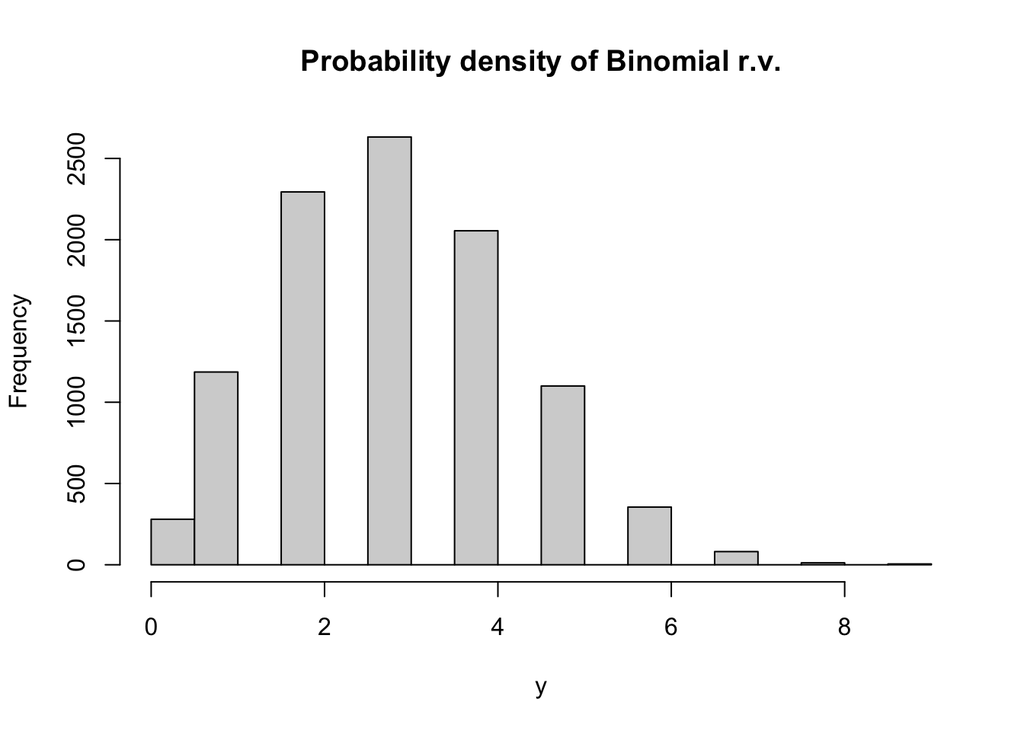

```r
# histogram
hist(y, main="Probability density of Binomial r.v.")
```

### Poisson distribution

A random variable distributed as a Poisson($\lambda$) has density equal to $p(x) = \lambda^x \frac{\exp(-\lambda)}{x!}$ for $x\geq 0$.

The mean and variance are E(x) = Var(x) = $\lambda$. We can compute the density p(x) using the function dpois( )

```r
# rate of success
lambda<-3
# number of success
x<-3
# density at x (probability of x successes in interval of time with rate of success lambda)
dpois(x,lambda)
```

```
## [1] 0.2240418
```

We can also compute the distribution function P(x) using the function ppois( )

```r
# distribution function at x  (probability of up to x successess in interval of time with rate of success lambda)
ppois(x,lambda)
```

```
## [1] 0.6472319
```

```r
# numbers to draw
k<-10000
# draw k numbers
z<-rpois(k, lambda)
```

and the we can display the density using a histogram:

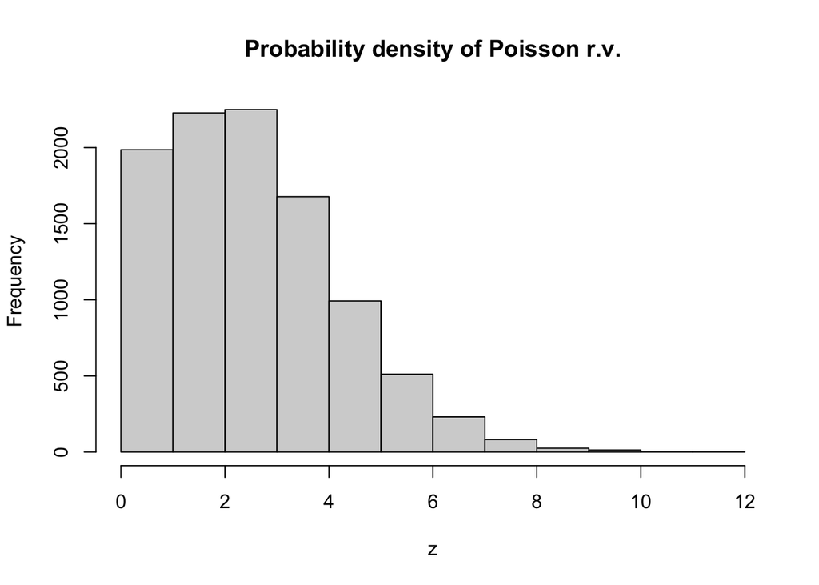

```r
# histogram
hist(z, main="Probability density of Poisson r.v.")
```